# cars info

```python
import numpy as np
import pandas as pd
import seaborn as sns
import matplotlib.ticker as mtick
import matplotlib.pyplot as plt
%matplotlib inline
```

**Dataset Info:** Data Set containing cars information about cars brand,model,Kilometers_Driven,Transmission,Milage,Engine,power,seats and price.

**TO READ THE DATA:**

```python
car=pd.read_excel(r"C:\Users\Dell\Desktop\CARS_INFO.xlsx")
car
```

|  | Car_ID | Brand | Model | Year | Kilometers_Driven | Fuel_Type | Transmission | Owner_Type | Mileage | Engine | Power | Seats | Price |
| --- | --- | --- | --- | --- | --- | --- | --- | --- | --- | --- | --- | --- | --- |
| 0 | 1 | Toyota | Corolla | 2018 | 50000 | Petrol | Manual | First | 15 | 1498 | 108 | 5 | 800000 |
| 1 | 2 | Honda | Civic | 2019 | 40000 | Petrol | Automatic | Second | 17 | 1597 | 140 | 5 | 1000000 |
| 2 | 3 | Ford | Mustang | 2017 | 20000 | Petrol | Automatic | First | 10 | 4951 | 395 | 4 | 2500000 |
| 3 | 4 | Maruti | Swift | 2020 | 30000 | Diesel | Manual | Third | 23 | 1248 | 74 | 5 | 600000 |
| 4 | 5 | Hyundai | Sonata | 2016 | 60000 | Diesel | Automatic | Second | 18 | 1999 | 194 | 5 | 850000 |
| ... | ... | ... | ... | ... | ... | ... | ... | ... | ... | ... | ... | ... | ... |
| 95 | 96 | Mercedes | C-Class | 2019 | 22000 | Diesel | Automatic | First | 16 | 1950 | 191 | 5 | 2900000 |
| 96 | 97 | Toyota | Innova Crysta | 2017 | 38000 | Diesel | Manual | Second | 13 | 2755 | 171 | 7 | 1400000 |
| 97 | 98 | Ford | EcoSport | 2018 | 26000 | Petrol | Manual | Third | 18 | 1497 | 121 | 5 | 750000 |
| 98 | 99 | Hyundai | Verna | 2019 | 24000 | Petrol | Automatic | Second | 17 | 1497 | 113 | 5 | 850000 |
| 99 | 100 | Tata | Altroz | 2020 | 18000 | Petrol | Manual | First | 20 | 1199 | 85 | 5 | 600000 |

100 rows × 13 columns

**TO SEE TOP 5 DATA**

```python
car.head()
```

|  | Car_ID | Brand | Model | Year | Kilometers_Driven | Fuel_Type | Transmission | Owner_Type | Mileage | Engine | Power | Seats | Price |
| --- | --- | --- | --- | --- | --- | --- | --- | --- | --- | --- | --- | --- | --- |
| 0 | 1 | Toyota | Corolla | 2018 | 50000 | Petrol | Manual | First | 15 | 1498 | 108 | 5 | 800000 |
| 1 | 2 | Honda | Civic | 2019 | 40000 | Petrol | Automatic | Second | 17 | 1597 | 140 | 5 | 1000000 |
| 2 | 3 | Ford | Mustang | 2017 | 20000 | Petrol | Automatic | First | 10 | 4951 | 395 | 4 | 2500000 |
| 3 | 4 | Maruti | Swift | 2020 | 30000 | Diesel | Manual | Third | 23 | 1248 | 74 | 5 | 600000 |
| 4 | 5 | Hyundai | Sonata | 2016 | 60000 | Diesel | Automatic | Second | 18 | 1999 | 194 | 5 | 850000 |

**TO SEE LAST 5 DATA**

```python
car.tail()
```

|  | Car_ID | Brand | Model | Year | Kilometers_Driven | Fuel_Type | Transmission | Owner_Type | Mileage | Engine | Power | Seats | Price |
| --- | --- | --- | --- | --- | --- | --- | --- | --- | --- | --- | --- | --- | --- |
| 95 | 96 | Mercedes | C-Class | 2019 | 22000 | Diesel | Automatic | First | 16 | 1950 | 191 | 5 | 2900000 |
| 96 | 97 | Toyota | Innova Crysta | 2017 | 38000 | Diesel | Manual | Second | 13 | 2755 | 171 | 7 | 1400000 |
| 97 | 98 | Ford | EcoSport | 2018 | 26000 | Petrol | Manual | Third | 18 | 1497 | 121 | 5 | 750000 |
| 98 | 99 | Hyundai | Verna | 2019 | 24000 | Petrol | Automatic | Second | 17 | 1497 | 113 | 5 | 850000 |
| 99 | 100 | Tata | Altroz | 2020 | 18000 | Petrol | Manual | First | 20 | 1199 | 85 | 5 | 600000 |

**SHAPE OF DATA**

```python
car.shape
```

```
(100, 13)
```

```python
car.values
```

```
array([[1, 'Toyota', 'Corolla', ..., 108, 5, 800000],
       [2, 'Honda', 'Civic', ..., 140, 5, 1000000],
       [3, 'Ford', 'Mustang', ..., 395, 4, 2500000],
       ...,
       [98, 'Ford', 'EcoSport', ..., 121, 5, 750000],
       [99, 'Hyundai', 'Verna', ..., 113, 5, 850000],
       [100, 'Tata', 'Altroz', ..., 85, 5, 600000]], dtype=object)
```

**INFORMATION**

```python
car.info()
```

```
<class 'pandas.core.frame.DataFrame'>
RangeIndex: 100 entries, 0 to 99
Data columns (total 13 columns):
 #   Column             Non-Null Count  Dtype
---  ------             --------------  -----
 0   Car_ID             100 non-null    int64
 1   Brand              100 non-null    object
 2   Model              100 non-null    object
 3   Year               100 non-null    int64
 4   Kilometers_Driven  100 non-null    int64
 5   Fuel_Type          100 non-null    object
 6   Transmission       100 non-null    object
 7   Owner_Type         100 non-null    object
 8   Mileage            100 non-null    int64
 9   Engine             100 non-null    int64
 10  Power              100 non-null    int64
 11  Seats              100 non-null    int64
 12  Price              100 non-null    int64
dtypes: int64(8), object(5)
memory usage: 10.3+ KB
```

```python
car.dtypes
```

```
Car_ID                int64
Brand                object
Model                object
Year                  int64
Kilometers_Driven     int64
Fuel_Type            object
Transmission         object
Owner_Type           object
Mileage               int64
Engine                int64
Power                 int64
Seats                 int64
Price                 int64
dtype: object
```

```python
car.describe()
```

|  | Car_ID | Year | Kilometers_Driven | Mileage | Engine | Power | Seats | Price |
| --- | --- | --- | --- | --- | --- | --- | --- | --- |
| count | 100.000000 | 100.00000 | 100.000000 | 100.000000 | 100.000000 | 100.000000 | 100.000000 | 1.000000e+02 |
| mean | 50.500000 | 2018.39000 | 28150.000000 | 17.210000 | 1855.230000 | 158.130000 | 5.230000 | 1.574000e+06 |
| std | 29.011492 | 1.17116 | 9121.375716 | 3.309902 | 631.311475 | 76.968137 | 0.750151 | 1.000265e+06 |
| min | 1.000000 | 2016.00000 | 10000.000000 | 10.000000 | 999.000000 | 68.000000 | 4.000000 | 4.500000e+05 |
| 25% | 25.750000 | 2017.75000 | 22000.000000 | 15.000000 | 1462.000000 | 103.000000 | 5.000000 | 7.000000e+05 |
| 50% | 50.500000 | 2018.00000 | 27000.000000 | 17.000000 | 1774.000000 | 148.000000 | 5.000000 | 1.300000e+06 |
| 75% | 75.250000 | 2019.00000 | 32000.000000 | 19.000000 | 2143.000000 | 187.000000 | 5.000000 | 2.500000e+06 |
| max | 100.000000 | 2021.00000 | 60000.000000 | 25.000000 | 4951.000000 | 396.000000 | 7.000000 | 4.000000e+06 |

1) Total Price of cars and also its 25%,50%,75% ,min,max is not in proper.

2) we cannot find averge price of all cars.

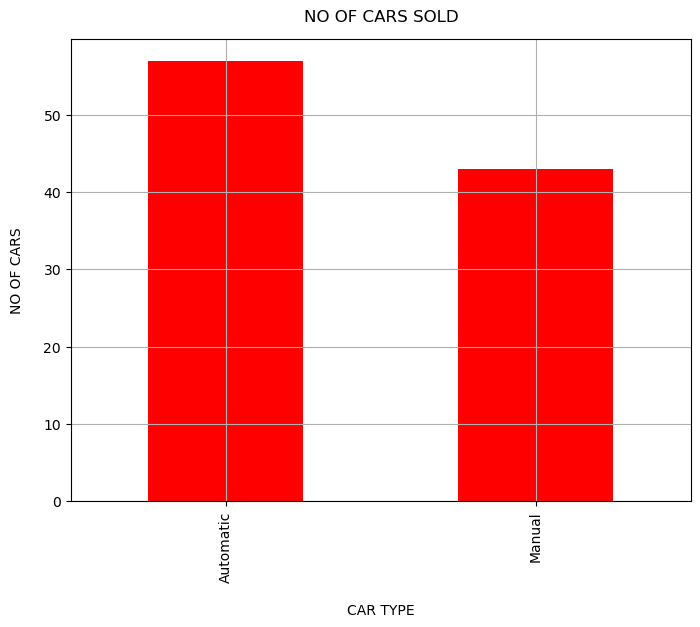

```python
car['Transmission'].value_counts().plot(kind = "bar", figsize=(8, 6),color="red")
plt.xlabel("CAR TYPE", labelpad=15)
plt.ylabel("NO OF CARS", labelpad=14)
plt.grid()
plt.title("NO OF CARS SOLD", y=1.02);
```

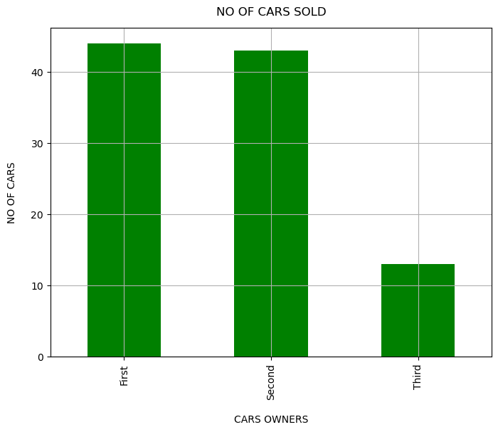

```python
car['Owner_Type'].value_counts().plot(kind = "bar", figsize=(8, 6),color="green")
plt.xlabel("CARS OWNERS", labelpad=15)
plt.ylabel("NO OF CARS", labelpad=14)
plt.grid()
plt.title("NO OF CARS SOLD", y=1.02);
```

**TOTAL CARS (AUTOMATIC OR MANUAL)**

```python
car["Transmission"].value_counts()
```

```
Transmission
Automatic    57
Manual       43
Name: count, dtype: int64
```

```python
car["Owner_Type"].value_counts()
```

```
Owner_Type
First     44
Second    43
Third     13
Name: count, dtype: int64
```

**PERCENTAGE OF CARS**

```python
car["Transmission"].value_counts()/len(car["Transmission"])*100
```

```
Transmission
Automatic    57.0
Manual       43.0
Name: count, dtype: float64
```

```python
car["Owner_Type"].value_counts()/len(car["Owner_Type"])*100
```

```
Owner_Type
First     44.0
Second    43.0
Third     13.0
Name: count, dtype: float64
```

- Data is unbalanced.
- So we analyse that out of 100 57% cars are automatic and 43% cars are manual
- 44% cars owners are First ,43% cars owners are Second and 13% cars owners are Third.

```python
car.isnull().sum()
```

```
Car_ID               0
Brand                0
Model                0
Year                 0
Kilometers_Driven    0
Fuel_Type            0
Transmission         0
Owner_Type           0
Mileage              0
Engine               0
Power                0
Seats                0
Price                0
dtype: int64
```

- there are not any null values in data

### Missing Data - Initial Intuition

- Here, we don't have any missing data.

## Data Cleaning

- creation of copy of our data.

```python
cars=car.copy()
cars
```

|  | Car_ID | Brand | Model | Year | Kilometers_Driven | Fuel_Type | Transmission | Owner_Type | Mileage | Engine | Power | Seats | Price |
| --- | --- | --- | --- | --- | --- | --- | --- | --- | --- | --- | --- | --- | --- |
| 0 | 1 | Toyota | Corolla | 2018 | 50000 | Petrol | Manual | First | 15 | 1498 | 108 | 5 | 800000 |
| 1 | 2 | Honda | Civic | 2019 | 40000 | Petrol | Automatic | Second | 17 | 1597 | 140 | 5 | 1000000 |
| 2 | 3 | Ford | Mustang | 2017 | 20000 | Petrol | Automatic | First | 10 | 4951 | 395 | 4 | 2500000 |
| 3 | 4 | Maruti | Swift | 2020 | 30000 | Diesel | Manual | Third | 23 | 1248 | 74 | 5 | 600000 |
| 4 | 5 | Hyundai | Sonata | 2016 | 60000 | Diesel | Automatic | Second | 18 | 1999 | 194 | 5 | 850000 |
| ... | ... | ... | ... | ... | ... | ... | ... | ... | ... | ... | ... | ... | ... |
| 95 | 96 | Mercedes | C-Class | 2019 | 22000 | Diesel | Automatic | First | 16 | 1950 | 191 | 5 | 2900000 |
| 96 | 97 | Toyota | Innova Crysta | 2017 | 38000 | Diesel | Manual | Second | 13 | 2755 | 171 | 7 | 1400000 |
| 97 | 98 | Ford | EcoSport | 2018 | 26000 | Petrol | Manual | Third | 18 | 1497 | 121 | 5 | 750000 |
| 98 | 99 | Hyundai | Verna | 2019 | 24000 | Petrol | Automatic | Second | 17 | 1497 | 113 | 5 | 850000 |
| 99 | 100 | Tata | Altroz | 2020 | 18000 | Petrol | Manual | First | 20 | 1199 | 85 | 5 | 600000 |

100 rows × 13 columns

```python
cars.info()
```

```
<class 'pandas.core.frame.DataFrame'>
RangeIndex: 100 entries, 0 to 99
Data columns (total 13 columns):
 #   Column             Non-Null Count  Dtype
---  ------             --------------  -----
 0   Car_ID             100 non-null    int64
 1   Brand              100 non-null    object
 2   Model              100 non-null    object
 3   Year               100 non-null    int64
 4   Kilometers_Driven  100 non-null    int64
 5   Fuel_Type          100 non-null    object
 6   Transmission       100 non-null    object
 7   Owner_Type         100 non-null    object
 8   Mileage            100 non-null    int64
 9   Engine             100 non-null    int64
 10  Power              100 non-null    int64
 11  Seats              100 non-null    int64
 12  Price              100 non-null    int64
dtypes: int64(8), object(5)
memory usage: 10.3+ KB
```

## Data Exploration

### Univariate Analysis

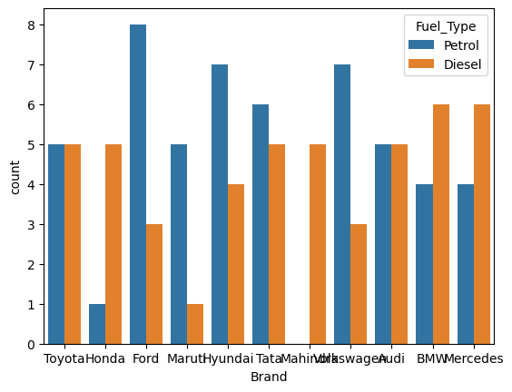

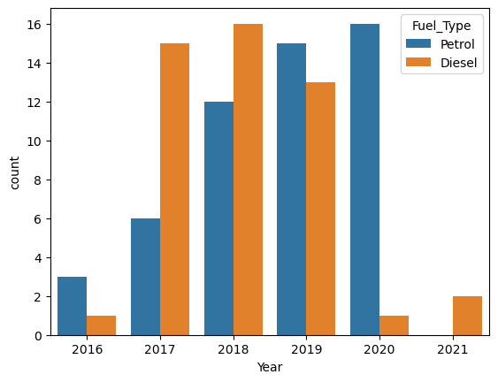

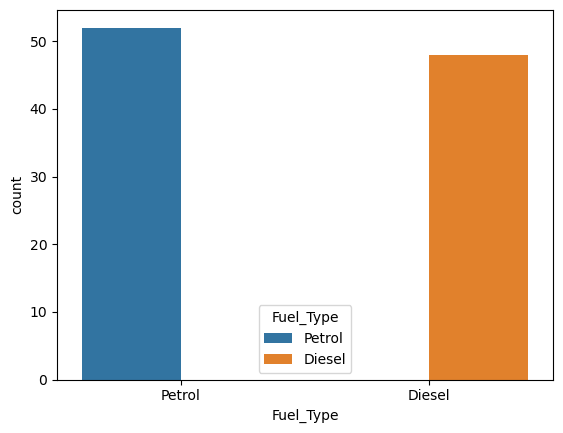

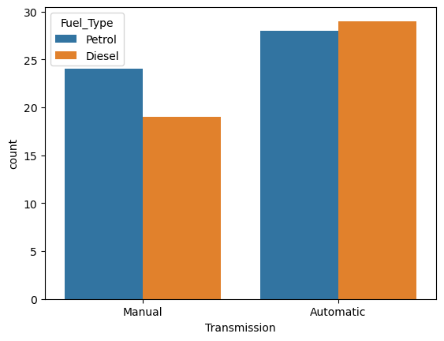

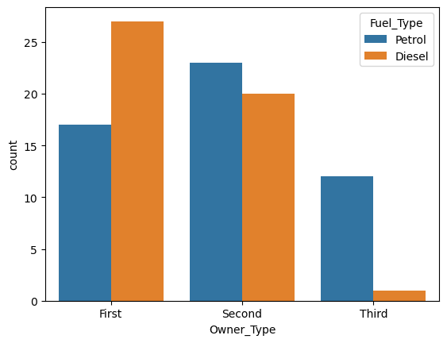

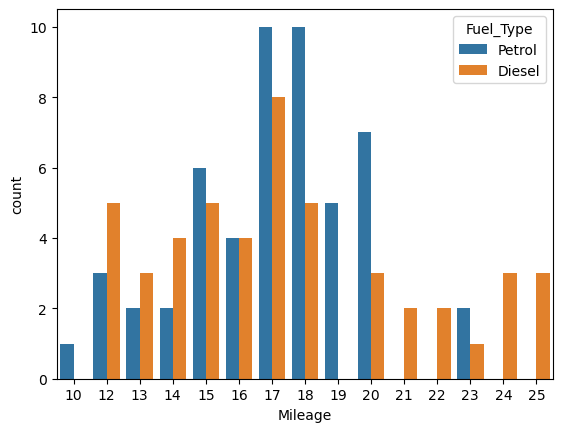

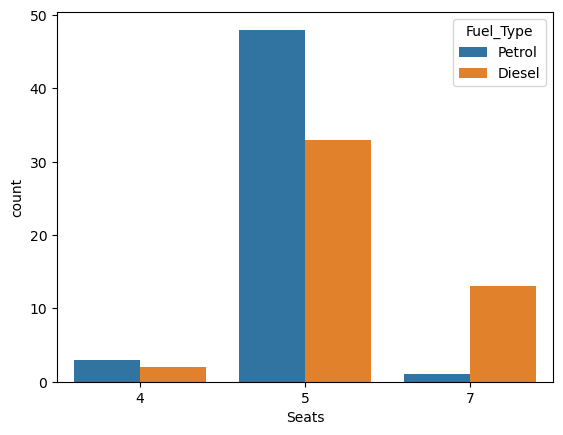

```python
for i, predictor in enumerate(cars.drop(columns=['Car_ID',"Model","Power","Price","Kilometers_Driven","Engine"])):
    plt.figure(i)
    sns.countplot(data=cars, x=predictor, hue='Fuel_Type')
```

**2.** Convert all the categorical variables into dummy variables

```python
cars_dummies = pd.get_dummies(cars)
cars_dummies.head()
```

|  | Car_ID | Year | Kilometers_Driven | Mileage | Engine | Power | Seats | Price | Brand_Audi | Brand_BMW | ... | Model_X5 | Model_XUV300 | Model_Yaris | Fuel_Type_Diesel | Fuel_Type_Petrol | Transmission_Automatic | Transmission_Manual | Owner_Type_First | Owner_Type_Second | Owner_Type_Third |
| --- | --- | --- | --- | --- | --- | --- | --- | --- | --- | --- | --- | --- | --- | --- | --- | --- | --- | --- | --- | --- | --- |
| 0 | 1 | 2018 | 50000 | 15 | 1498 | 108 | 5 | 800000 | False | False | ... | False | False | False | False | True | False | True | True | False | False |
| 1 | 2 | 2019 | 40000 | 17 | 1597 | 140 | 5 | 1000000 | False | False | ... | False | False | False | False | True | True | False | False | True | False |
| 2 | 3 | 2017 | 20000 | 10 | 4951 | 395 | 4 | 2500000 | False | False | ... | False | False | False | False | True | True | False | True | False | False |
| 3 | 4 | 2020 | 30000 | 23 | 1248 | 74 | 5 | 600000 | False | False | ... | False | False | False | True | False | False | True | False | False | True |
| 4 | 5 | 2016 | 60000 | 18 | 1999 | 194 | 5 | 850000 | False | False | ... | False | False | False | True | False | True | False | False | True | False |

5 rows × 84 columns

**4.RELATIONSHIP BETWEEN CARS BRAND AND ITS MILEAGE**

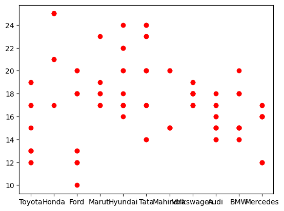

```python
plt.scatter(data=cars,x='Brand', y="Mileage",color="red")
plt.show()
```

**Build a corelation of all predictors with Mileage**

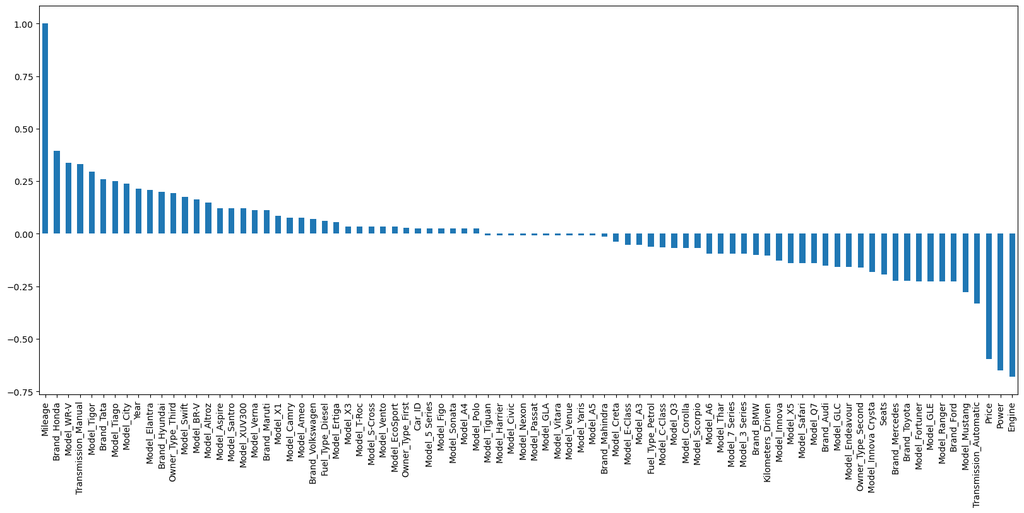

```python
plt.figure(figsize=(20,8))
cars_dummies.corr()['Mileage'].sort_values(ascending = False).plot(kind='bar')
```

```python
cars_dummies.corr()
```

|  | Car_ID | Year | Kilometers_Driven | Mileage | Engine | Power | Seats | Price | Brand_Audi | Brand_BMW | ... | Model_X5 | Model_XUV300 | Model_Yaris | Fuel_Type_Diesel | Fuel_Type_Petrol | Transmission_Automatic | Transmission_Manual | Owner_Type_First | Owner_Type_Second | Owner_Type_Third |
| --- | --- | --- | --- | --- | --- | --- | --- | --- | --- | --- | --- | --- | --- | --- | --- | --- | --- | --- | --- | --- | --- |
| Car_ID | 1.000000 | 0.059904 | -0.227442 | 0.026140 | -0.027965 | 0.027637 | -0.021582 | 0.037105 | 0.009238 | 0.020786 | ... | 0.081658 | 0.111352 | 0.042066 | -0.088063 | 0.088063 | -0.087118 | 0.087118 | -0.058623 | 0.048632 | 0.014937 |
| Year | 0.059904 | 1.000000 | -0.741176 | 0.213177 | -0.355122 | -0.249446 | -0.252598 | -0.232687 | -0.311797 | 0.174492 | ... | -0.047812 | 0.074782 | 0.197376 | -0.252843 | 0.252843 | -0.211993 | 0.211993 | 0.187402 | -0.325356 | 0.202352 |
| Kilometers_Driven | -0.227442 | -0.741176 | 1.000000 | -0.104437 | 0.112340 | -0.026732 | 0.396443 | -0.051104 | 0.126713 | -0.233225 | ... | -0.002361 | -0.033843 | -0.159768 | 0.323762 | -0.323762 | -0.030157 | 0.030157 | -0.107879 | 0.217109 | -0.160378 |
| Mileage | 0.026140 | 0.213177 | -0.104437 | 1.000000 | -0.680949 | -0.648894 | -0.194581 | -0.595252 | -0.152835 | -0.102227 | ... | -0.139243 | 0.121025 | -0.009109 | 0.060292 | -0.060292 | -0.331015 | 0.331015 | 0.029117 | -0.159650 | 0.192045 |
| Engine | -0.027965 | -0.355122 | 0.112340 | -0.680949 | 1.000000 | 0.805709 | 0.179179 | 0.714465 | 0.076346 | 0.286860 | ... | 0.259896 | -0.081471 | -0.081698 | 0.258043 | -0.258043 | 0.421374 | -0.421374 | 0.092875 | 0.158888 | -0.370985 |
| ... | ... | ... | ... | ... | ... | ... | ... | ... | ... | ... | ... | ... | ... | ... | ... | ... | ... | ... | ... | ... | ... |
| Transmission_Automatic | -0.087118 | -0.211993 | -0.030157 | -0.331015 | 0.421374 | 0.574349 | -0.111225 | 0.676484 | 0.289518 | 0.289518 | ... | 0.124079 | -0.164477 | -0.164477 | 0.066306 | -0.066306 | 1.000000 | -1.000000 | -0.084639 | 0.305590 | -0.324933 |
| Transmission_Manual | 0.087118 | 0.211993 | 0.030157 | 0.331015 | -0.421374 | -0.574349 | 0.111225 | -0.676484 | -0.289518 | -0.289518 | ... | -0.124079 | 0.164477 | 0.164477 | -0.066306 | 0.066306 | -1.000000 | 1.000000 | 0.084639 | -0.305590 | 0.324933 |
| Owner_Type_First | -0.058623 | 0.187402 | -0.107879 | 0.029117 | 0.092875 | 0.093459 | 0.023752 | 0.159788 | 0.174595 | -0.094013 | ... | -0.126629 | -0.126629 | 0.161165 | 0.237102 | -0.237102 | -0.084639 | 0.084639 | 1.000000 | -0.769891 | -0.342645 |
| Owner_Type_Second | 0.048632 | -0.325356 | 0.217109 | -0.159650 | 0.158888 | 0.143327 | 0.057101 | 0.098798 | -0.087529 | 0.181790 | ... | 0.164477 | 0.164477 | -0.124079 | -0.025875 | 0.025875 | 0.305590 | -0.305590 | -0.769891 | 1.000000 | -0.335744 |
| Owner_Type_Third | 0.014937 | 0.202352 | -0.160378 | 0.192045 | -0.370985 | -0.348939 | -0.119117 | -0.381290 | -0.128852 | -0.128852 | ... | -0.055222 | -0.055222 | -0.055222 | -0.311873 | 0.311873 | -0.324933 | 0.324933 | -0.342645 | -0.335744 | 1.000000 |

84 rows × 84 columns

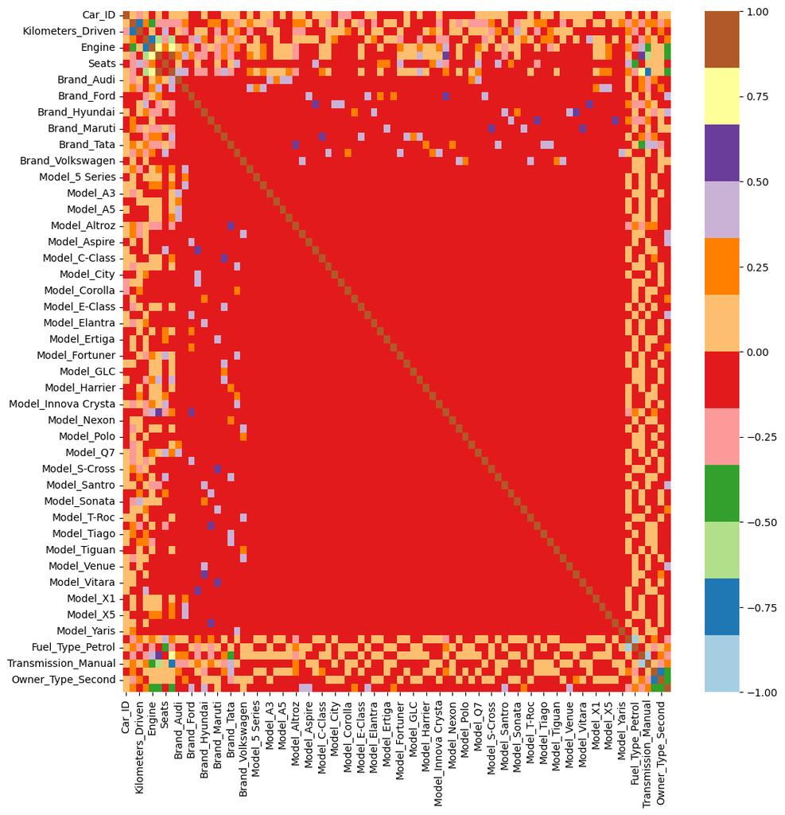

```python
plt.figure(figsize=(12,12))
sns.heatmap(cars_dummies.corr(), cmap="Paired")
```

### Bivariate Analysis

```python
new_df1_target0=cars.loc[cars["Mileage"]==0]
new_df1_target1=cars.loc[cars["Mileage"]==1]
```

```python
def uniplot(df,col,title,hue =None):

    sns.set_style('whitegrid')
    sns.set_context('talk')
    plt.rcParams["axes.labelsize"] = 20
    plt.rcParams['axes.titlesize'] = 22
    plt.rcParams['axes.titlepad'] = 30


    temp = pd.Series(data = hue)
    fig, ax = plt.subplots()
    width = len(df[col].unique()) + 7 + 4*len(temp.unique())
    fig.set_size_inches(width , 8)
    plt.xticks(rotation=45)
    plt.yscale('log')
    plt.title(title)
    ax = sns.countplot(data = cars, x= col, order=cars[col].value_counts().index,hue = hue,palette='bright')

    plt.show()
```

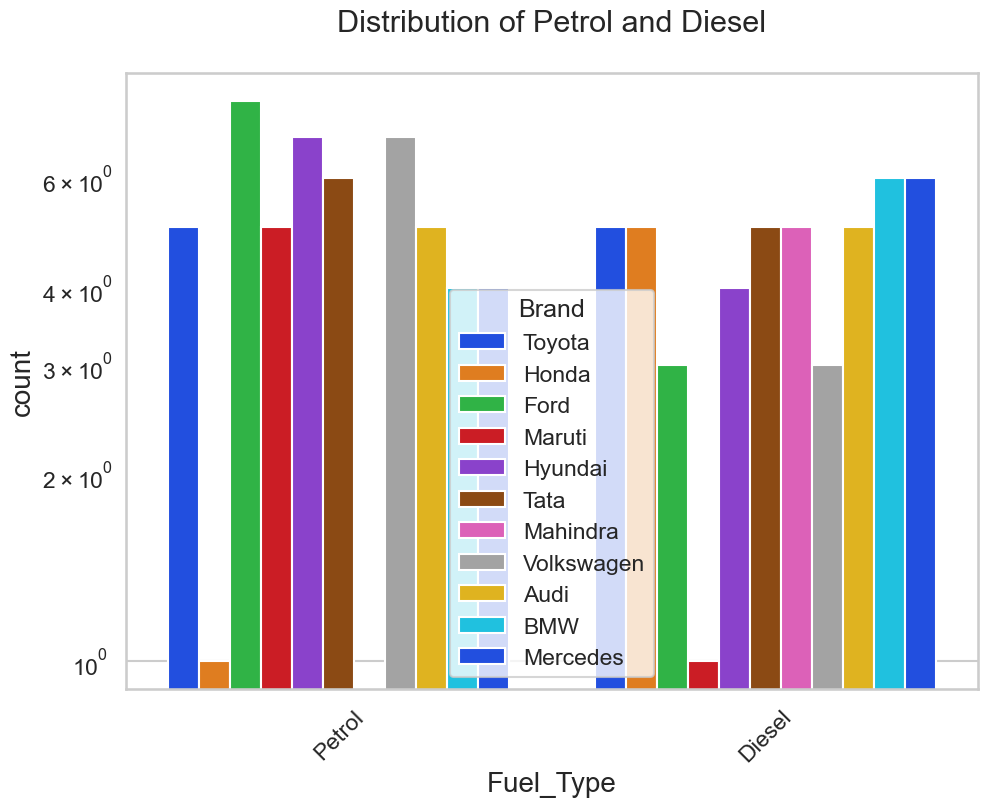

```python
uniplot(new_df1_target1,col='Fuel_Type',title='Distribution of Petrol and Diesel',hue='Brand')
```

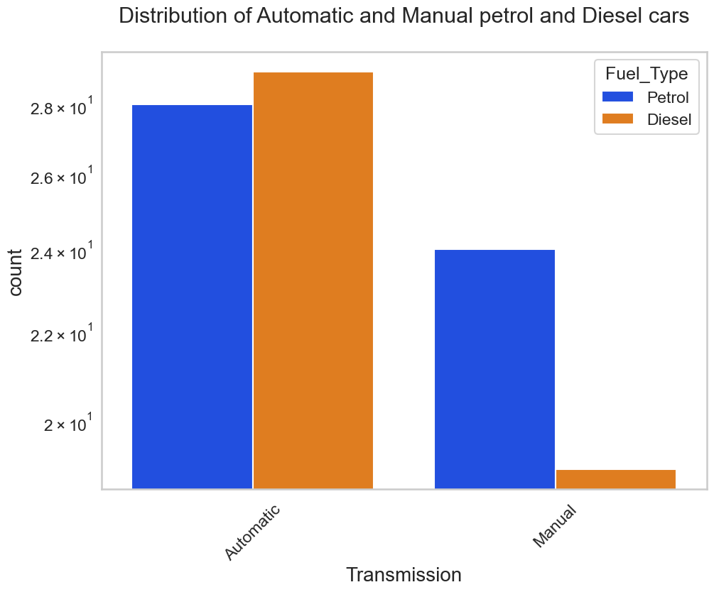

```python
uniplot(new_df1_target1,col='Transmission',title='Distribution of Automatic and Manual petrol and Diesel cars',hue='Fuel_Type')
```

```python
cars["Brand"].value_counts()
```

```
Brand
Ford          11
Hyundai       11
Tata          11
Toyota        10
Volkswagen    10
Audi          10
BMW           10
Mercedes      10
Honda          6
Maruti         6
Mahindra       5
Name: count, dtype: int64
```

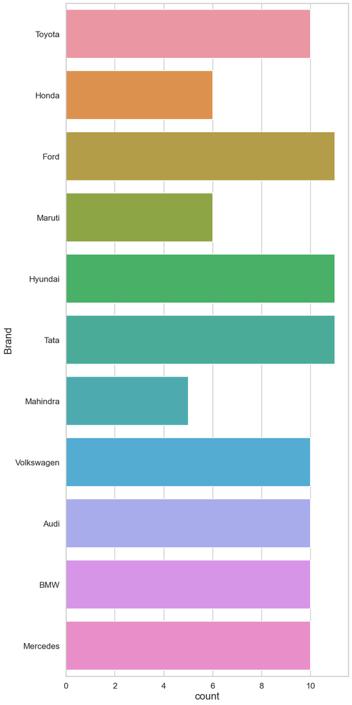

```python
plt.figure(figsize=(10,24))
sns.countplot(data=cars,y="Brand")
```

- no of cars of Each Brand

```python
cars["Model"].value_counts()
```

```
Model
Mustang          3
Altroz           3
C-Class          3
Verna            3
Fortuner         2
S-Cross          2
Vitara           2
WR-V             2
Ameo             2
A3               2
7 Series         2
GLE              2
Yaris            2
Ranger           2
Santro           2
Tigor            2
T-Roc            2
BR-V             2
Elantra          2
Q7               2
X5               2
GLA              2
Camry            2
Venue            2
Tiago            2
XUV300           2
Vento            2
A5               2
3 Series         2
Innova Crysta    2
Safari           2
EcoSport         2
Aspire           2
E-Class          2
X3               2
A6               2
Passat           2
Thar             2
Creta            1
Swift            1
Sonata           1
Nexon            1
Scorpio          1
Polo             1
A4               1
X1               1
Endeavour        1
City             1
Harrier          1
Ertiga           1
Civic            1
Tiguan           1
Q3               1
5 Series         1
GLC              1
Innova           1
Figo             1
Corolla          1
Name: count, dtype: int64
```

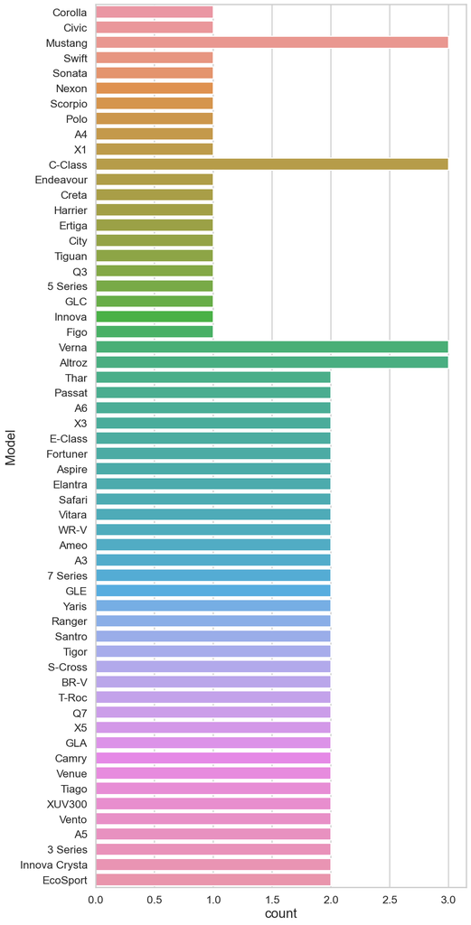

```python
plt.figure(figsize=(10,24))
sns.countplot(data=cars,y="Model")
```

- No of cars of each Model

```python
cars["Transmission"].value_counts()
```

```
Transmission
Automatic    57
Manual       43
Name: count, dtype: int64
```

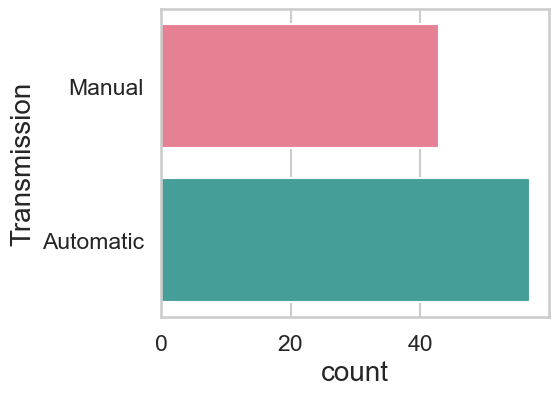

```python
plt.figure(figsize=(5,4))
sns.countplot(data=cars,y="Transmission",palette="husl")
```

```python
cars["Fuel_Type"].value_counts()
```

```
Fuel_Type
Petrol    52
Diesel    48
Name: count, dtype: int64
```

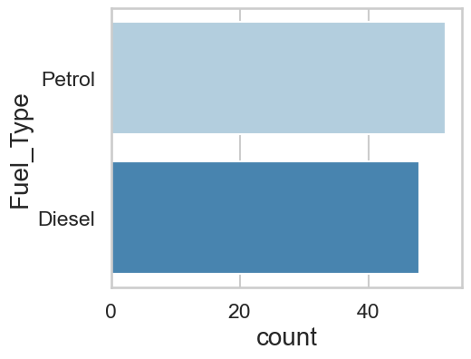

```python
plt.figure(figsize=(5,4))
sns.countplot(data=cars,y="Fuel_Type",palette="Blues")
```

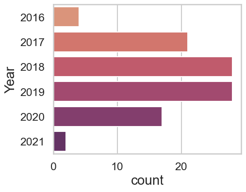

```python
plt.figure(figsize=(5,4))
sns.countplot(data=cars,y="Year",palette="flare")
```

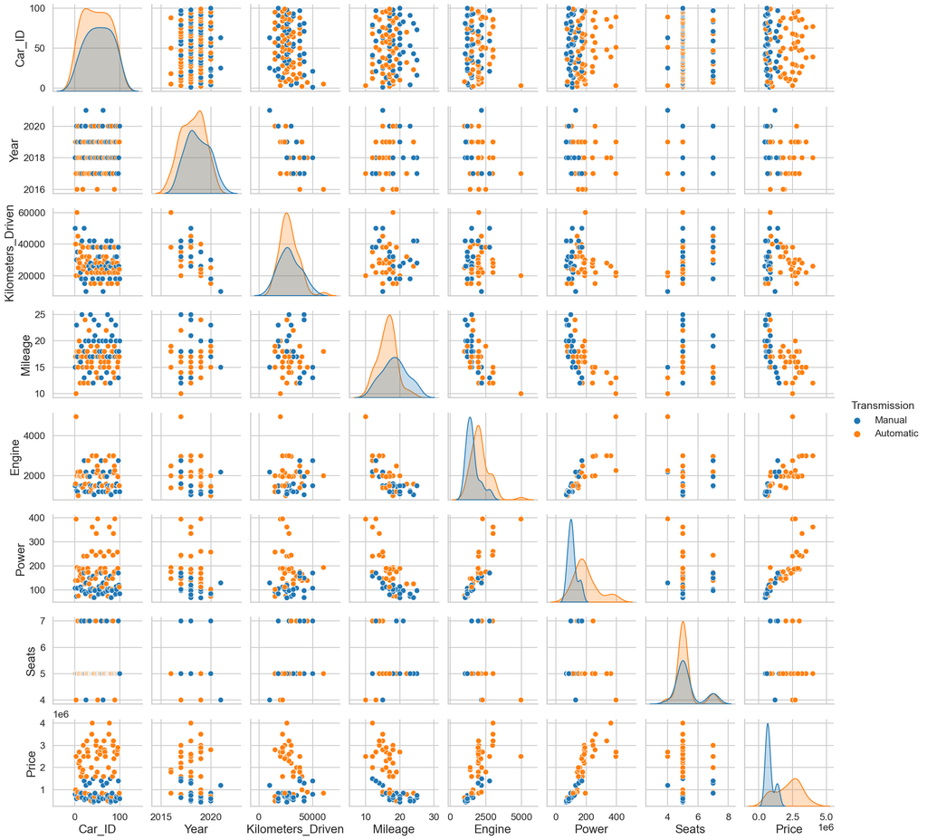

```python
plt.figure(figsize=(10,10))
sns.pairplot(data=cars,hue="Transmission")
```

## Conclusion

**In this blog, we have employed Python and its data visualization libraries to explore a car dataset. By creating visualizations like [barplot,countplot,scatterplot,pairplot], we were able to effectively analyze the Univarient and Bivariate Analysis. Our visualization revealed [Brand,Model,Transmission,Fuel_type,Mileage,Price]. By utilizing Python for data analysis and visualization, we were able to transform raw data into actionable knowledge, highlighting the importance of these techniques in various academic fields.**